# Investigate IMDB Dataset

- Introduction
- Data Cleaning & Wrangling
- Exploratory Data Analysis
- Conclusions

## Introduction

- In this analysis we will know an important informations about movies and movies production companies from the IMDB dataset and answer some questions.
- 1-Is there a relation between the rates and years? And What is it lead to?
- 2-What is the most rate is given to the movies? And What is it?
- 3-Is there any relation between movie production and years? And What is it lead to?
- 4-Is there any relation between the revenue and the years? And What is it lead to?
- 5-Is the movie production companies spend more budgets over the years? And What is it lead to?
- 6-What are the top 5 movies made a profit? And What is the highest one?
- 7-What is the highest genre?
- 8-What are the top 10 Directors by rate? And What is the highest one?
- 9-What are Top 10 directors by Total revenue for the movies they directed?
- 10-What are Top 10 directors by Avrage revenue for the movies they directed?

### For the analysis included in the notebook we will take look at all the abouve questions.

# Research Question 1 (Is there a relation between the rates and years?)

#### This question will determine is there any relation between the rates and years and the relationship strength and answer the question: Is lately the rates increased?.

#### We chose a scatter plot because the 2 variables is quantitative and to measure the distribution between the release years and average rating to know if there is a relationship or not and the strength of it.

#### The next scatter plot shows that over the years and increasing the number of movies more low rates came out and slightly a small number of higher rates.

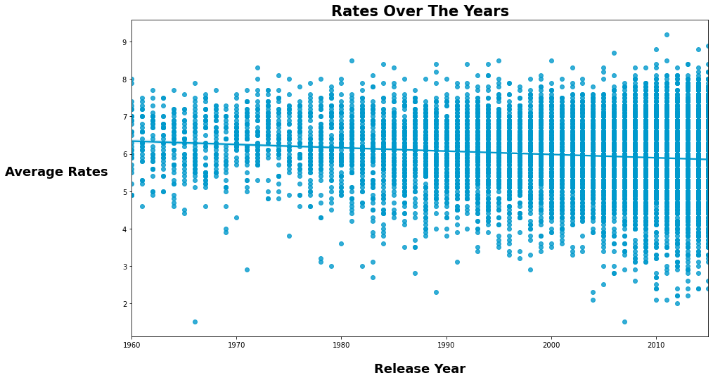

# Research Question 2 (What is the most rate is given to the movies?)

#### We want to know the most rate the people give to the movies.

#### The next histogram shows that most highest movie rates are between 5 to 7 approximately.

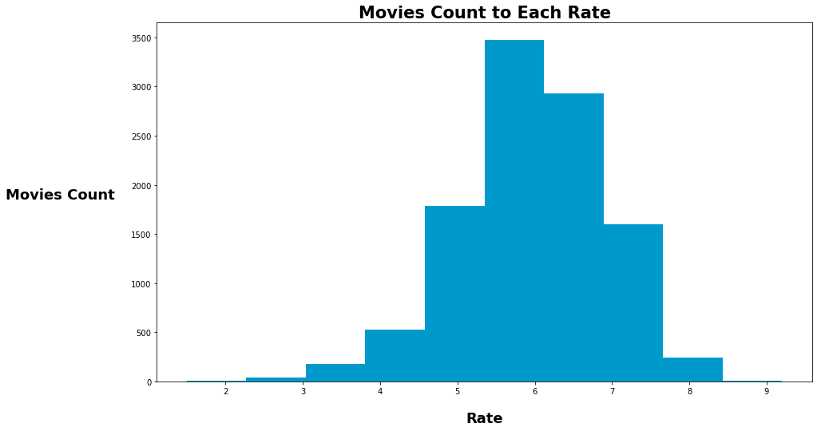

### The last shape show us the range of the rating most gived to movies is between 5.3 and 6.1 and thats is the list of the most rates gived to the movies

- 6.1 : 496 rate
- 6.0 : 495 rate
- 5.8 : 486 rate
- 5.9 : 473 rate
- 6.2 : 464 rate
- 6.3 : 461 rate
- 6.5 : 457 rate
- 6.4 : 446 rate
- 5.7 : 415 rate
- 6.6 : 413 rate
- 5.6 : 412 rate

#### The highest one is 6.1/10

# Research Question 3 (Is there any relation between movies production and years ?)

#### We need to know if the movies produced lately more than in the past or not?

#### The next histogram shows that movies production slowly grew between 1960/1994, and highly Increased between 1994/2017 approximately.

#### We choose histogram because it is simple and enough for our question to know if there any increase or decrease in movies over the years.

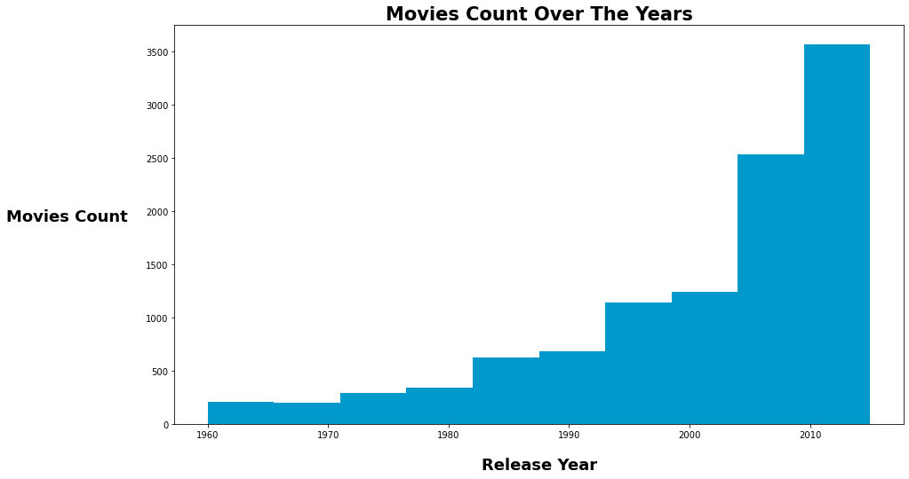

# Research Question 4 (Is there any relation between the revenue and the years?)

#### We will use the scatter plot to know if there is relation between the revenue and the years to detrimne if lately the movies make more profit or not.

#### the next scatter plot shows us that the movie profits is slightly increased over the years

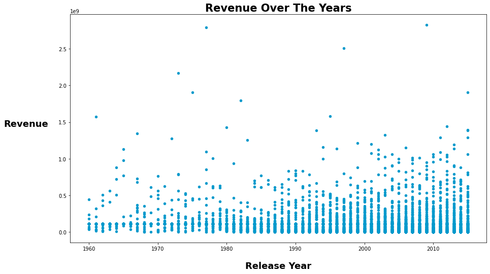

#### We can determine that lately the movies make a slightly higher profit, considering the huge number of movies lately.

# Research Question 5 (Is the movie production companies spend more budgets over the years?)

#### We will use scatter plot to know if the production companies spend more budgets on movies lately or not.

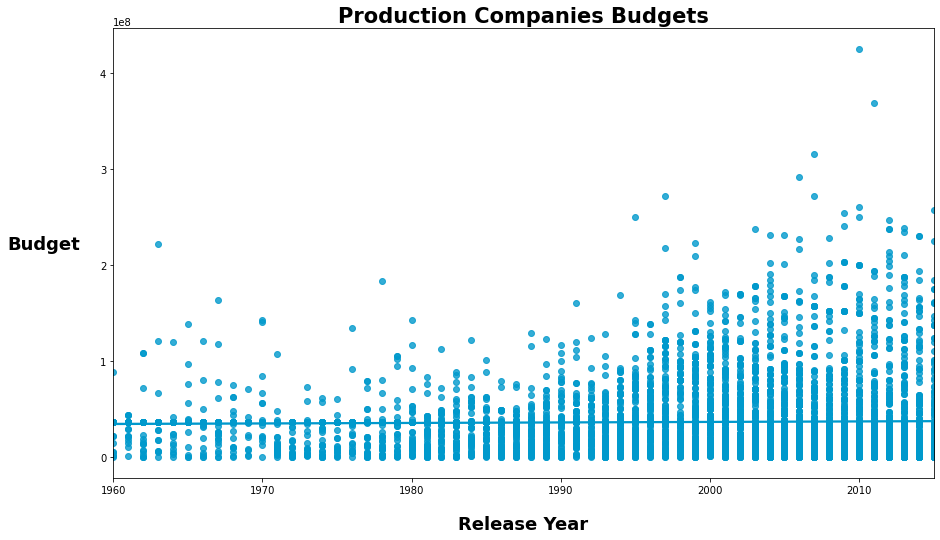

# Research Question 6 (What are the top 5 movies made a profit?)

#### We will use bar chart to shows the top 5 movies made a profit.

#### The next shape shows the top 5 movies made a profit.

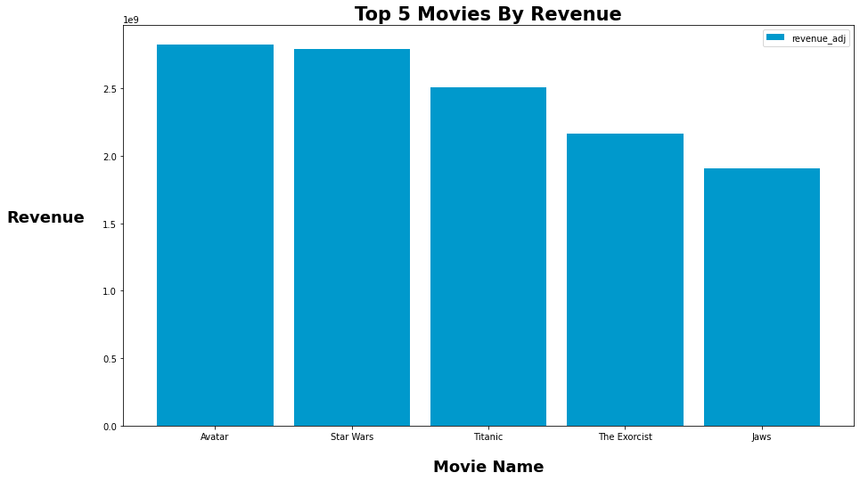

#### We can determine the top 5 movies making a profit and the highest movie made a profit was Avatar.

# Research Question 7 (What is the highest genre?)

#### We will use a bar chart to determine the highest genre used in the movies.

#### The next shape shows movie count associated to each genre.

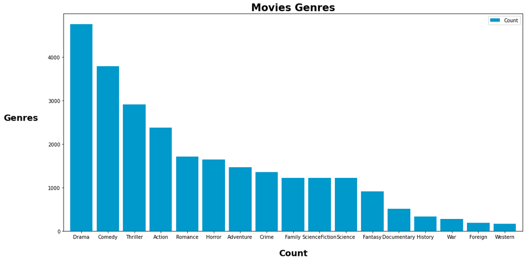

#### After this shape, we can determine that the Drama has the most movies produced over the years and the minimum is the Western genre.

## Research Question 8 (What are the top 10 Directors by rate?)

#### We will use bar chart to determine the top 10 directors take a rate to know the best directors.

#### The next shape shows The top 10 Directors associated by their movies rating.

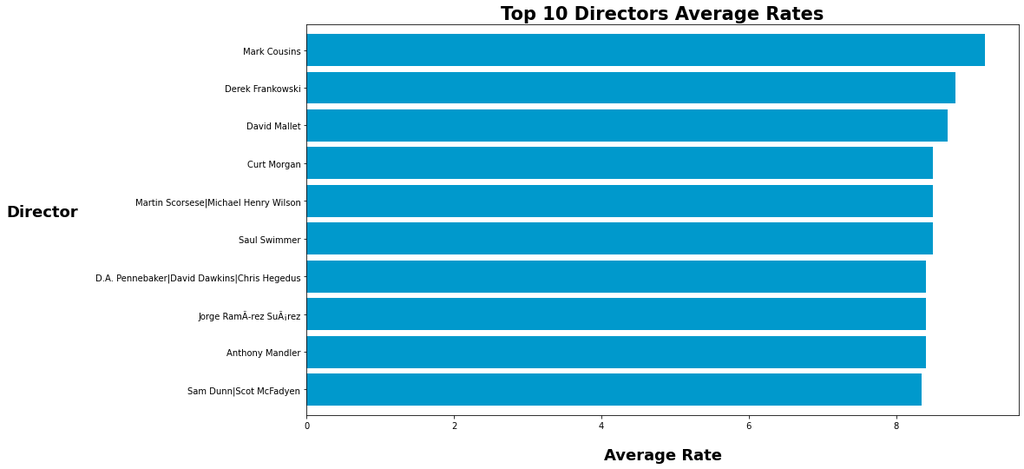

#### After looking at the director's shape we will determine that mark cousins is the best director based on the rates he gained.

## Research Question 9 (What are Top 10 directors by total revenue for the movies they directed?)

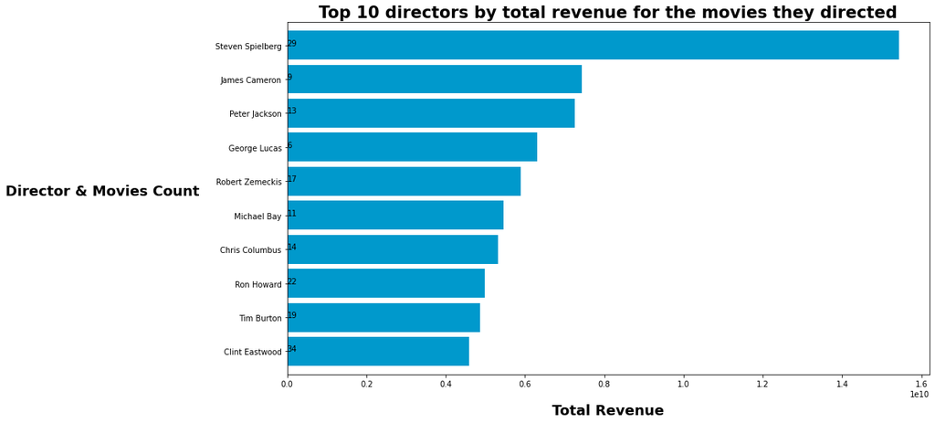

#### We can see the total revenue for the top 10 directors for the movies they directed and we can notice that there is some of them have a huge number of movies but a low amount of revenue so in the next visual we will show the top 10 directors but by the average revenue for their movies to determine the top 10 successful directors in making a profit for their movies.

### Research Question 10 (What are Top 10 directors by Avrage revenue for the movies they directed?)

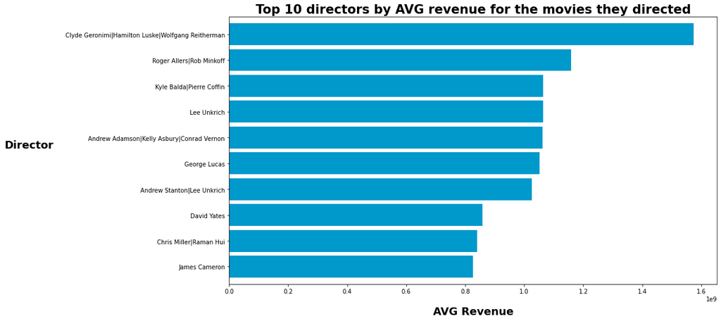

#### We now can determine the top 10 successful directors in making a profit for their movies.

## Conclusions

### Results: Our data leads us to:

> We answered some important questions that provided us a valuable information about movies.

> We determined that over the years and increasing the number of movies more low rates came out and slightly a small number of higher rates.

> We figured out that the most highest movie rates are between 5/10 to 7/10 approximately and the highest rate givin to the movies is 6.1/10.

> We determined that the movies production slowly grew between 1960-1994, and highly Increased between 1994-2017 approximately.

> We determined that the movie profits is slightly increased over the years.

> We figured out the top 5 movies made a profit and the highest one is "Avatar".

> We figured out the top 10 directors by rates and the highest one is Mark Cousins.

> The Highest movie rate is for The Story of Film: An Odyssey by 9.2/10 and it have only 14 rates and it is missleading to the top movie so the movie after this movie has 8.4 rate and not a little amount of rates by 5754 is The Shawshank Redemption for the director Frank Darabont.

> Woody Allen has the highest number of movies directed by 45 movie.

> In the last 2 visuals, we can determine the top successfully 10 directors made a profit for the movies they directed.

> The average revenue for all movies is higher than the average budget by 35 million dollars approximately, so we can determine that movie production is a profitable field.

> The average runtime for the movies is 1.7 hours.

> We have also strange information that there are movies that have a 900 minutes runtime!

## limitations: There are a couple of limitations faced our analysis:

1. Most of our data is categorical which limits us to make correlations between factors
2. There are a lot of null values, misleading data, and outliers, which these samples are not an effective representation of the population.

###### I used Stack Overflow ,GeeksforGeeks ,Seaborn documentation ,Data to Fish and pandas documentation.